# CSCI E-63C Week 10 Problem Set

# Sub-problem 3 (15 points): varying counts of predictors

For all possible pairwise combinations of the numbers of variables associated with outcome (`nClassVars=2` and `5`) and those not associated with the outcome (`nNoiseVars=1`, `3` and `10`) – six pairwise combinations in total – obtain and present graphically test errors from random forest, LDA and KNN. Choose signal magnitude (`deltaClass`) and training data sample size so that this simulation yields non-trivial results – noticeable variability in the error rates across those six pairwise combinations of attribute counts. Describe the results: what is the impact of the increase of the number of attributes associated with the outcome on the classifier performance? What about the number of attributes not associated with outcome - does it affect classifier error rate? Are different classifier methods affected by these simulation parameters in a similar way?

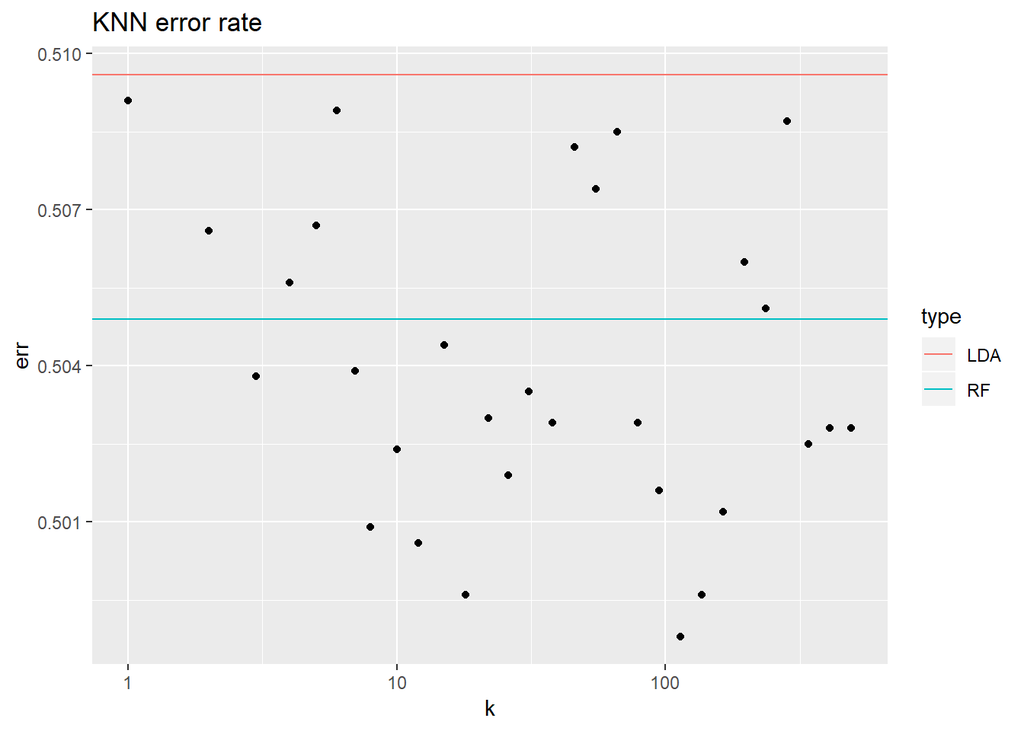

```r
# default obs and delta for all combos of classVars and noiseVars
nObs = 500
deltaClass = 2

# create a function to generate plots for each combo
varyClassNoiseGen = function(nObs=500, nClassVars, nNoiseVars, deltaClass=2, classTrain=1){

  data.500 = trainDataGen(nObs, nClassVars, nNoiseVars, deltaClass, classTrain, xyzTrain.500)
  classTrain.500 = unlist(data.500[1])
  classTrain.500 = factor(classTrain.500 > 0)

  # RF
  rf.500 = randomForestGen(xyzTrain.500, xyzTest.10K, classTrain.500, classTest.10K)

  # lda
  lda.500 = ldaGen(xyzTrain.500, xyzTest.10K, classTrain.500, classTest.10K)


  # knn
  knn.500 = knnGen(500, xyzTrain.500, xyzTest.10K, classTrain.500, classTest.10K, lda.500, rf.500)
  return(knn.500)
}

# nClass Variables = 2
varyClassNoiseGen(nObs, 2, 1, deltaClass, 1) # noise = 1
```

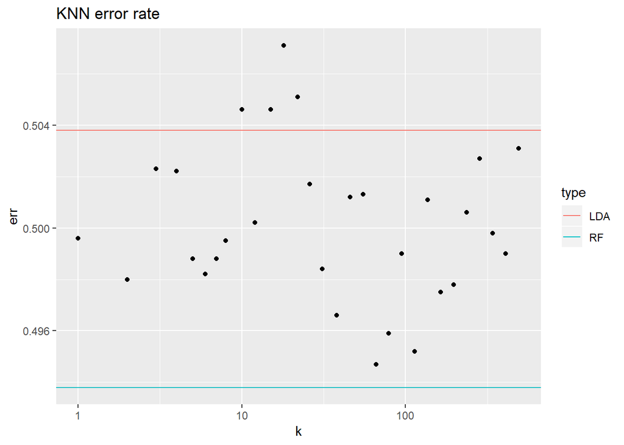

```r
varyClassNoiseGen(nObs, 2, 3, deltaClass, 1) # noise = 3
```

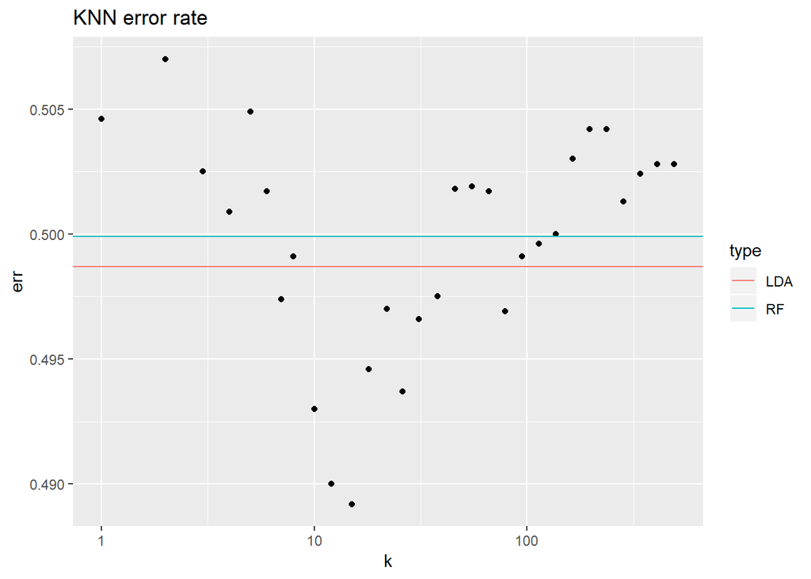

```r
varyClassNoiseGen(nObs, 2, 10, deltaClass, 1) # noise = 10
```